# Data Visualizations

**EXERCISE 3.2.4**

```r
library(tidyverse)
```

**Run ggplot(data = mpg). What do you see?**

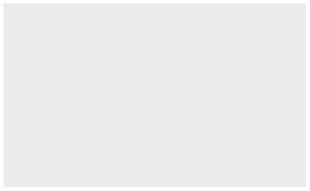

```r
ggplot(data = mpg)
```

**ANSWER**

empty graph

**How many rows are in mpg? How many columns?**

```r
?mpg
```

**ANSWER**

A data frame with 234 rows and 11 variables

**What does the drv variable describe? Read the help for ?mpg to find out.**

**ANSWER**

f = front-wheel drive, r = rear wheel drive, 4 = 4wd

**Make a scatterplot of hwy vs cyl**

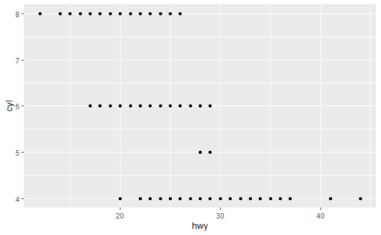

```r
ggplot(data=mpg)+
geom_point(mapping = aes(x=hwy, y=cyl))
```

**What happens if you make a scatterplot of class vs drv? Why is the plot not useful?**

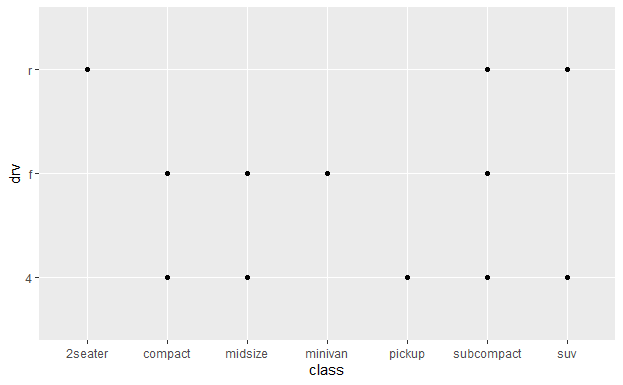

```r
ggplot(data=mpg)+
geom_point(mapping = aes(x=class, y=drv))
```

**ANSWER**

The plot is not useful because varible class is categorical

**3.3.1 EXERCISES**

**What’s gone wrong with this code? Why are the points not blue?**

**SOLUTION**

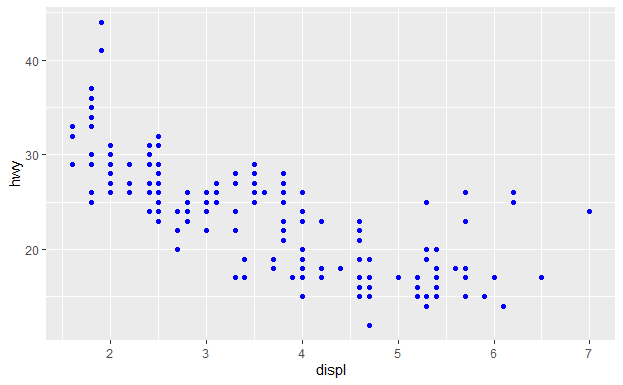

```r
ggplot(data = mpg) +
  geom_point(mapping = aes(x = displ, y = hwy), color = "blue")
```

**Which variables in mpg are categorical? Which variables are continuous? (Hint: type ?mpg to read the documentation for the dataset). How can you see this information when you run mpg?**

```r
?mpg
```

```r
str(mpg)
```

```
Classes ‘tbl_df’, ‘tbl’ and 'data.frame':   234 obs. of  11 variables:
 $ manufacturer: chr  "audi" "audi" "audi" "audi" ...
 $ model       : chr  "a4" "a4" "a4" "a4" ...
 $ displ       : num  1.8 1.8 2 2 2.8 2.8 3.1 1.8 1.8 2 ...
 $ year        : int  1999 1999 2008 2008 1999 1999 2008 1999 1999 2008 ...
 $ cyl         : int  4 4 4 4 6 6 6 4 4 4 ...
 $ trans       : chr  "auto(l5)" "manual(m5)" "manual(m6)" "auto(av)" ...
 $ drv         : chr  "f" "f" "f" "f" ...
 $ cty         : int  18 21 20 21 16 18 18 18 16 20 ...
 $ hwy         : int  29 29 31 30 26 26 27 26 25 28 ...
 $ fl          : chr  "p" "p" "p" "p" ...
 $ class       : chr  "compact" "compact" "compact" "compact" ...
```

**ANSWER**

categorical - drv,class,fl,trans,manufacturer,model,trans

**Map a continuous variable to color, size, and shape. How do these aesthetics behave differently for categorical vs. continuous variables?**

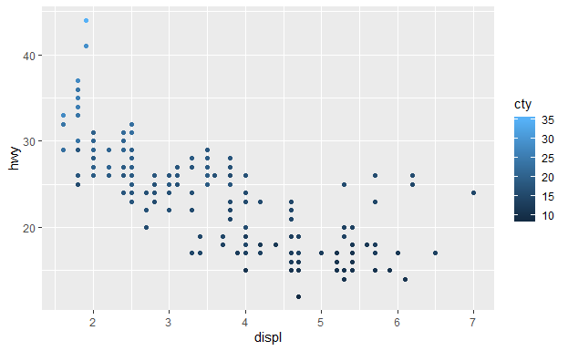

```r
ggplot(data = mpg) +
  geom_point(mapping = aes(x = displ, y = hwy, color = cty))
```

```r
NA
```

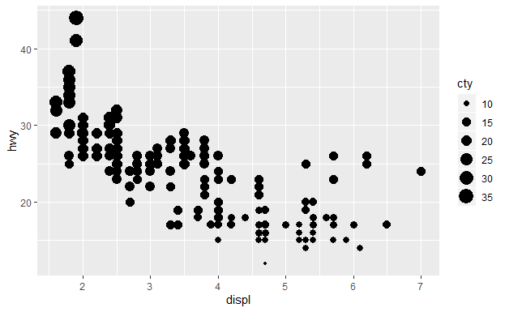

```r
ggplot(data = mpg) +
  geom_point(mapping = aes(x = displ, y = hwy, size = cty))
```

```r
NA
```

```r
ggplot(data = mpg) +
  geom_point(mapping = aes(x = displ, y = hwy, shape = cty))
```

```
Error: A continuous variable can not be mapped to shape
```

**What happens if you map the same variable to multiple aesthetics?**

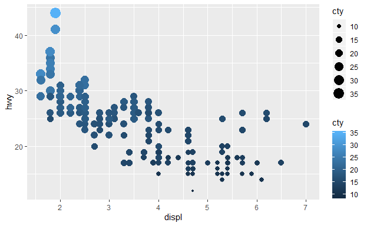

```r
ggplot(data = mpg) +
  geom_point(mapping = aes(x = displ, y = hwy, size=cty, color=cty))
```

```r
NA
```

**What does the stroke aesthetic do? What shapes does it work with? (Hint: use ?geom_point)**

Use the stroke aesthetic to modify the width of the border

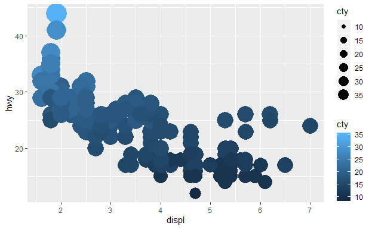

```r
ggplot(data=mpg)+
  geom_point(mapping=aes(x = displ, y = hwy, size=cty, color=cty,stroke = 5))
```

**What happens if you map an aesthetic to something other than a variable name, like aes(colour = displ < 5)? Note, you’ll also need to specify x and y.**

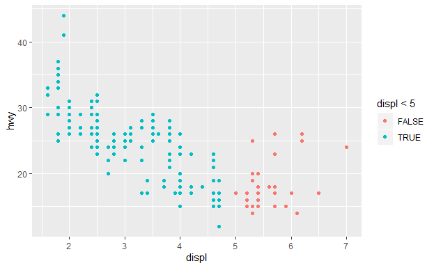

```r
ggplot(data=mpg)+
  geom_point(mapping=aes(x = displ, y = hwy, color=displ<5))
```

**3.5.1 EXERCISE**

**What happens if you facet on a continuous variable?**

facet_wrap() will work with continous variable but not as useful as working with categorical variable.

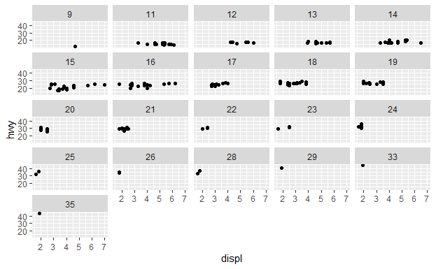

```r
ggplot(data=mpg)+
  geom_point(mapping=aes(x = displ, y = hwy))+
  facet_wrap(~cty)
```

**What do the empty cells in plot with facet_grid(drv ~ cyl) mean? How do they relate to this plot?**

No combination of data points

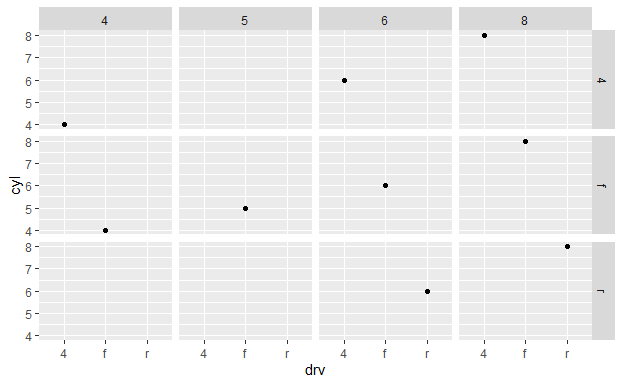

```r
ggplot(data = mpg) +
  geom_point(mapping = aes(x = drv, y = cyl))+
facet_grid(drv ~ cyl)
```

**What plots does the following code make? What does . do?**

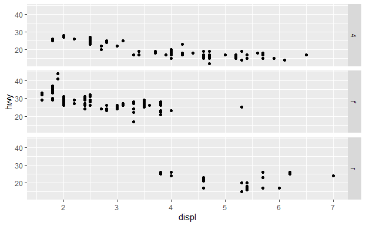

```r
ggplot(data = mpg) +
  geom_point(mapping = aes(x = displ, y = hwy)) +
  facet_grid(drv ~ .)
```

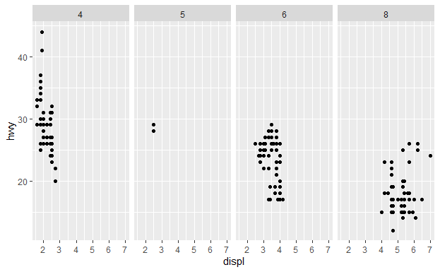

```r
ggplot(data = mpg) +
  geom_point(mapping = aes(x = displ, y = hwy)) +
  facet_grid(. ~ cyl)
```

conclusion

rows are facetted by the variable on the left hand side of ~. and columns are facetted by the variable on the right hand side of .~

**Take the first faceted plot in this section:**

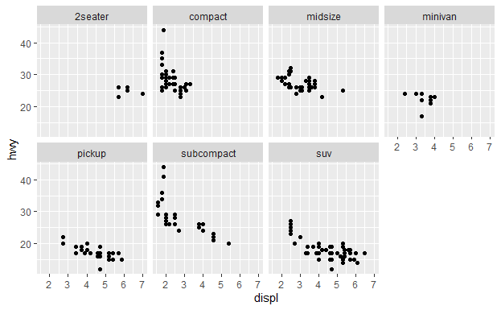

```r
ggplot(data = mpg) +
  geom_point(mapping = aes(x = displ, y = hwy)) +
  facet_wrap(~ class, nrow = 2)
```

**What are the advantages to using faceting instead of the colour aesthetic? What are the disadvantages? How might the balance change if you had a larger dataset?**

Advantages of using faceting is that it is useful for categorical variables,to split your plot into facets, subplots that each display one subset of the data making focus on particular facets alone. in contrast colour aesthetic having display of multiple colors with increase in categorical features can cause confusion.

Disadvantage of using faceting is that since the points are on separate plots direct comparison may not be direct

**Read ?facet_wrap. What does nrow do? What does ncol do? What other options control the layout of the individual panels? Why doesn’t facet_grid() have nrow and ncol arguments?**

```r
?facet_wrap()
```

nrow, ncol  
Number of rows and columns.

**When using facet_grid() you should usually put the variable with more unique levels in the columns. Why?**

One logical reason is that since the dependent variables are usually plotted on the y-axis, it is much easier to compare the highs and lows and the trends of the variables if the plots are placed side by side.

**EXERCISE 3.6.1**

**What geom would you use to draw a line chart? A boxplot? A histogram? An area chart?**

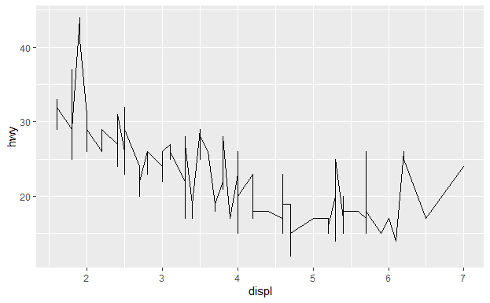

```r
ggplot(data = mpg)+
  geom_line(mapping=aes(x=displ,y=hwy))
```

```r
NA
```

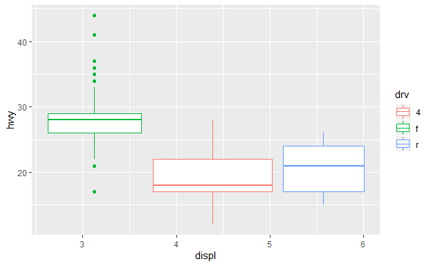

```r
ggplot(data = mpg)+
  geom_boxplot(mapping=aes(x=displ,y=hwy,color=drv))
```

```r
NA
```

```r
ggplot(data = mpg)+
  geom_histogram()
```

[output not shown]

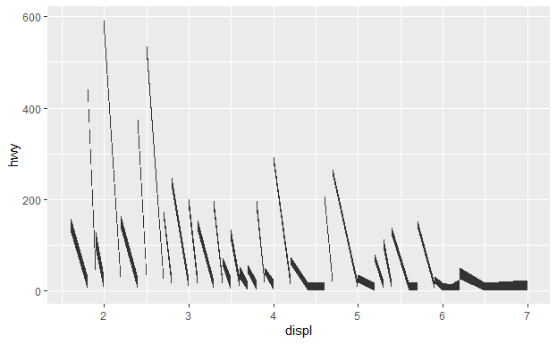

```r
ggplot(data = mpg)+
  geom_area(mapping=aes(x=displ,y=hwy))
```

```r
NA
```

**Run this code in your head and predict what the output will look like. Then, run the code in R and check your predictions.**

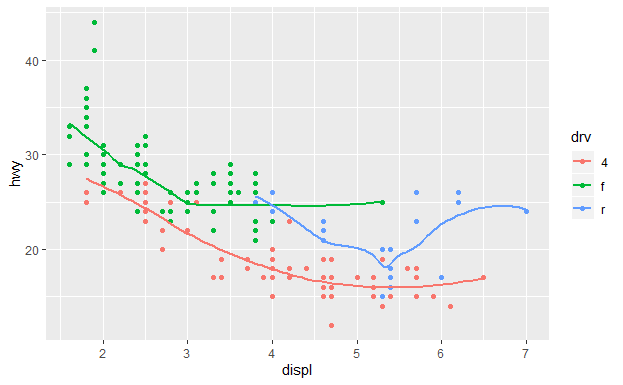

```r
ggplot(data = mpg, mapping = aes(x = displ, y = hwy, color = drv)) +
  geom_point() +
  geom_smooth(se = FALSE)
```

**What does show.legend = FALSE do?**

Removes a legend that is used to explain which levels correspond to which values.

**What happens if you remove it?**

You see the legend explaining what levels correspond to which values.

**Why do you think I used it earlier in the chapter?**

To show how to remove a legend

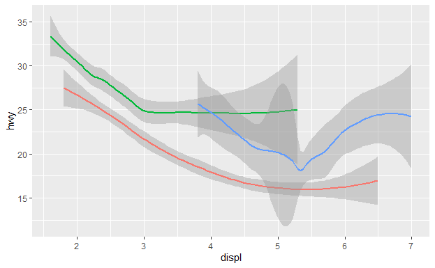

```r
ggplot(data = mpg) +
  geom_smooth(
    mapping = aes(x = displ, y = hwy, color = drv),
    show.legend = FALSE
  )
```

**What does the se argument to geom_smooth() do**

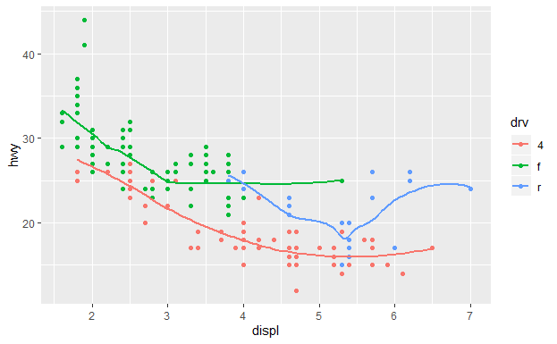

```r
ggplot(data = mpg, mapping = aes(x = displ, y = hwy, color = drv)) +
  geom_point() +
  geom_smooth(se = FALSE)
```

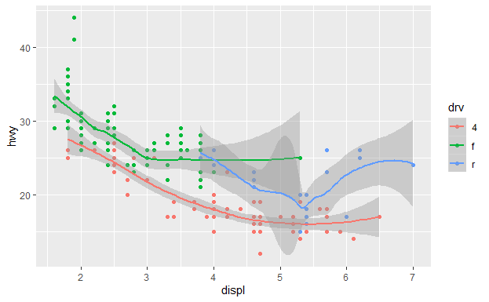

```r
ggplot(data = mpg, mapping = aes(x = displ, y = hwy, color = drv)) +
  geom_point() +
  geom_smooth(se = TRUE)
```

**Will these two graphs look different? Why/why not?**

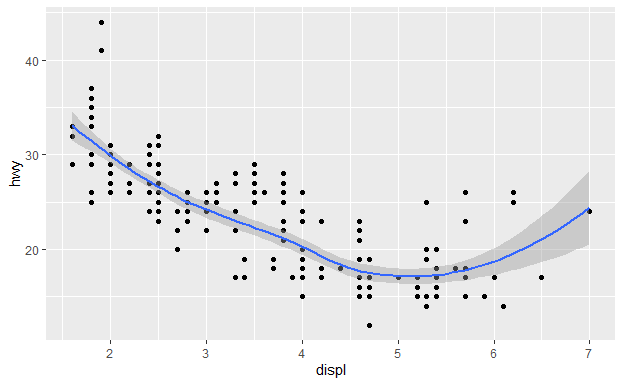

```r
ggplot(data = mpg, mapping = aes(x = displ, y = hwy)) +
  geom_point() +
  geom_smooth()
```

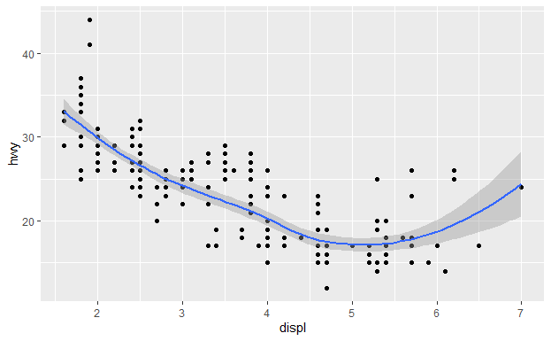

```r
ggplot() +
  geom_point(data = mpg, mapping = aes(x = displ, y = hwy)) +
  geom_smooth(data = mpg, mapping = aes(x = displ, y = hwy))
```

**ANSWER**

No the two graphs will not look different, because both functions produce the same output. The difference is that second function only does duplication in your code, which is not good practice for obtaining clean code.

**Recreate the R code necessary to generate the following graphs.**

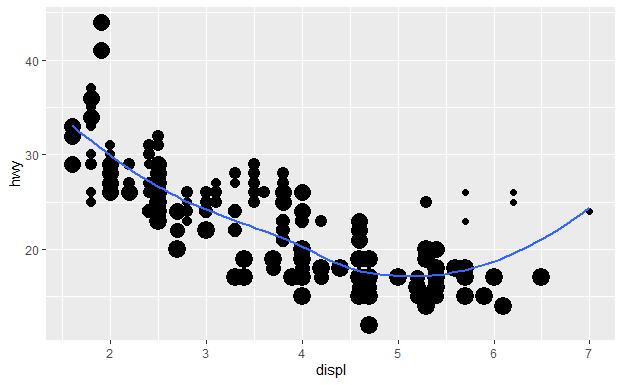

```r
ggplot(data = mpg, mapping = aes(x = displ, y = hwy)) +
  geom_point(mapping = aes(size=class),show.legend = FALSE) +
  geom_smooth(se=FALSE)
```

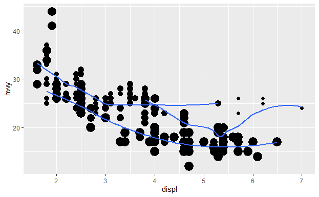

```r
ggplot(data = mpg, mapping = aes(x = displ, y = hwy)) +
  geom_point(mapping = aes(size=class),show.legend = FALSE) +
  geom_smooth(mapping = aes(group=drv),se=FALSE)
```

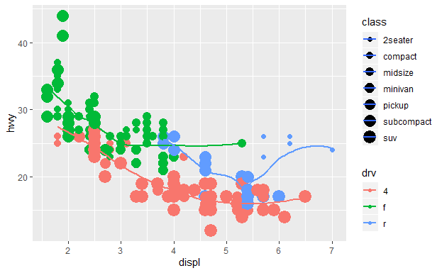

```r
ggplot(data = mpg, mapping = aes(x = displ, y = hwy)) +
  geom_point(mapping = aes(color=drv,size=class),show.legend = TRUE) +
  geom_smooth(mapping = aes(color=drv),show.legend = TRUE,se=FALSE)
```

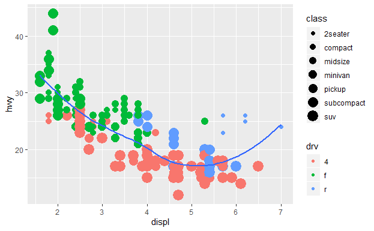

```r
ggplot(data = mpg, mapping = aes(x = displ, y = hwy)) +
  geom_point(mapping = aes(color=drv,size=class),show.legend = TRUE) +
  geom_smooth(show.legend = FALSE,se=FALSE)
```

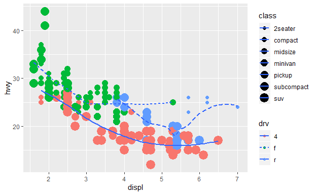

```r
ggplot(data = mpg, mapping = aes(x = displ, y = hwy)) +
  geom_point(mapping = aes(color=drv,size=class),show.legend = TRUE) +
  geom_smooth(mapping = aes(linetype=drv),show.legend = TRUE,se=FALSE)
```

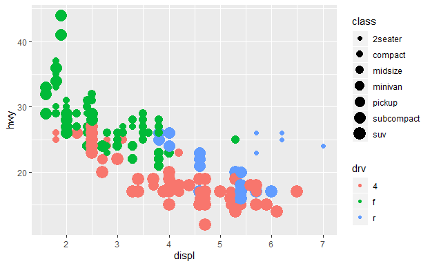

```r
ggplot(data = mpg, mapping = aes(x = displ, y = hwy,size=class)) +
  geom_point(mapping = aes(color=drv),show.legend = TRUE)
```

```r
NA
```

**EXERCISE 3.7.1**

**What is the default geom associated with stat_summary()? How could you rewrite the previous plot to use that geom function instead of the stat function?**

```r
?stat_summary()
```

**PREVIOUS PLOT**

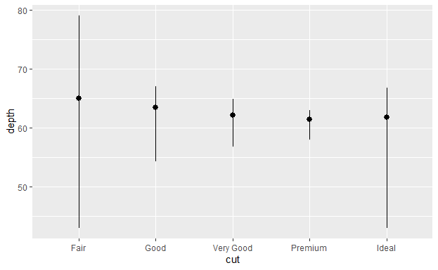

```r
ggplot(data = diamonds) +
  stat_summary(
    mapping = aes(x = cut, y = depth),
    fun.ymin = min,
    fun.ymax = max,
    fun.y = median
  )
```

**SOLUTION**

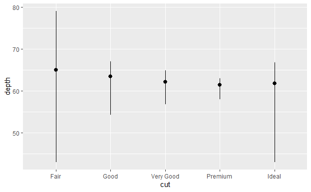

```r
ggplot(data = diamonds) +
  geom_pointrange(mapping = aes(x = cut, y = depth),
                  stat = "summary",
                  fun.ymin = min,
                  fun.ymax = max,
                  fun.y = median)
```

```r
?stat_summary()
```

**What does geom_col() do? How is it different to geom_bar()?**

```r
?geom_bar
```

**ANSWER**

geom_bar() makes the height of the bar proportional to the number of cases in each group (or if the weight aesthetic is supplied, the sum of the weights). If you want the heights of the bars to represent values in the data, use geom_col() instead. geom_bar() uses stat_count() by default: it counts the number of cases at each x position. geom_col() uses stat_identity(): it leaves the data as is.